# Get started

Run, inspect, change, and export one panel simulation.

This tutorial runs a ready-made design, inspects the known effects, and then builds a second design from reusable components. The full page runs in a few seconds.

## 1 Install and import

```bash
uv add "pypanelsim @ git+https://github.com/apoorvalal/pypanelsim.git"
```

```python
import matplotlib.pyplot as plt
import numpy as np

from pypanelsim import core, designs, primitives
```

The three modules have distinct jobs:

- `core` contains the simulator, results, and random-stream tools.
- `primitives` contains reusable feature, assignment, outcome, and effect models.
- `designs` contains ready-made simulation designs.

## 2 Run a ready-made design

```python
panel = designs.classic_factor(overlap=1.0, seed=17)

print("name:", panel.name)
print("shape:", panel.shape)
print("treated units:", panel.treated_units.size)
print("adoption period:", panel.adoption_times[panel.ever_treated][0])
print("true ATT:", round(panel.true_att, 3))
```

```
name: classic_factor
shape: (200, 50)
treated units: 40
adoption period: 40
true ATT: 1.1
```

The design has a low-rank untreated outcome and one treated cohort. The `overlap` argument changes the separation between treated and control factor loadings.

## 3 Inspect the result

```python
print(panel.outcome.shape)
print(panel.treatment.shape)
print(panel.untreated_outcome.shape)
print(panel.effect_surface.shape)

identity_error = abs(
    panel.outcome - panel.untreated_outcome - panel.treatment_effect
).max()
print("largest identity error:", identity_error)
```

```
(200, 50)
(200, 50)
(200, 50)
(200, 50)
largest identity error: 1.5543122344752192e-15
```

`effect_surface[i, t]` is the effect that unit $i$ would have at time $t$ if treated. `treatment_effect[i, t]` is the realized effect and is zero when the cell is untreated.

## 4 Inspect known effects

```python
event_truth = panel.truth.event_study()
print(event_truth.keys())

for event_time, effect in zip(
    event_truth["event_time"][:5],
    event_truth["effect"][:5],
    strict=True,
):
    print(int(event_time), round(float(effect), 3))
```

```
dict_keys(['event_time', 'effect', 'supported_cohorts', 'target_unit_count'])
-40 0.0
-39 0.0
-38 0.0
-37 0.0
-36 0.0
```

The simulator knows the effect in every cell, so these values do not depend on an estimator.

## 5 Compose two-way fixed effects and factors

Two-way fixed effects and low-rank factors are reusable outcome models. Combine them with `SumOutcomeModel`.

```python
outcome_model = primitives.SumOutcomeModel(
    models=(
        primitives.TwoWayFixedEffectsOutcome(
            unit_effect_scale=1.0,
            time_effect_scale=0.5,
            noise_scale=0.2,
        ),
        primitives.LowRankFactorOutcome(
            rank=2,
            loading_scale=1.0,
            factor_scale=0.7,
        ),
    ),
    weights=(1.0, 1.0),
)

simulator = core.PanelSimulator(
    name="fixed_effects_plus_factors",
    dimensions=core.PanelDimensions(n_units=200, n_periods=40),
    assignment=primitives.RandomizedSingleCohortAssignment(
        n_treated=80,
        adoption_period=25,
    ),
    outcome_model=outcome_model,
    effect_model=primitives.LinearRampEffect(slope=0.2),
)

composed_panel = simulator.simulate(seed=17)
print(composed_panel.metadata["outcome"]["model"])
print(round(composed_panel.true_att, 3))
```

```
SumOutcomeModel
1.6
```

## 6 Compare the two panels

The first panel uses a ready-made one-factor design. The second combines two-way fixed effects with two latent factors. Sorting units by adoption time makes the treated block visible.

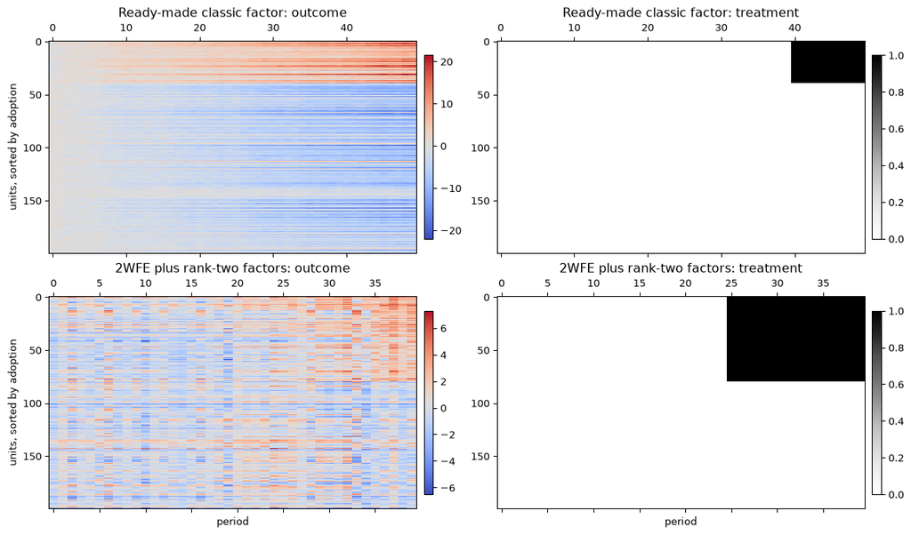

Figure 1: Observed outcomes and treatment for a ready-made factor design and a design built from two-way fixed effects and low-rank factors.

```python
comparisons = (
    ("Ready-made classic factor", panel),
    ("2WFE plus rank-two factors", composed_panel),
)
figure, axes = plt.subplots(2, 2, figsize=(12, 7), constrained_layout=True)

for row, (label, draw) in enumerate(comparisons):
    order = np.argsort(draw.adoption_times, kind="stable")
    outcome_image = axes[row, 0].matshow(
        draw.outcome[order],
        aspect="auto",
        cmap="coolwarm",
    )
    treatment_image = axes[row, 1].matshow(
        draw.treatment[order],
        aspect="auto",
        cmap="Greys",
        vmin=0.0,
        vmax=1.0,
    )
    axes[row, 0].set_title(f"{label}: outcome")
    axes[row, 1].set_title(f"{label}: treatment")
    axes[row, 0].set_ylabel("units, sorted by adoption")
    figure.colorbar(outcome_image, ax=axes[row, 0], fraction=0.025, pad=0.02)
    figure.colorbar(treatment_image, ax=axes[row, 1], fraction=0.025, pad=0.02)

for axis in axes[-1]:
    axis.set_xlabel("period")
plt.show()
```

The simulator calls the components in a fixed order, validates their shapes, and checks the causal identity before it returns a panel.

## 7 Change one assumption

Replace random assignment with selection on observed and unobserved features. The outcome and treatment-effect models do not change.

```python
selected_simulator = core.PanelSimulator(
    name="selected_fixed_effects_plus_factors",
    dimensions=core.PanelDimensions(n_units=200, n_periods=40),
    feature_model=primitives.GaussianUnitFeatures(
        n_observables=2,
        n_unobservables=1,
    ),
    assignment=primitives.BinaryLogitAssignment(
        adoption_period=25,
        intercept=-0.4,
        observable_coefficients=(0.7, -0.4),
        unobservable_coefficients=(0.8,),
    ),
    outcome_model=outcome_model,
    effect_model=primitives.LinearRampEffect(slope=0.2),
)

selected_panel = selected_simulator.simulate(seed=17)
print("treated units:", selected_panel.treated_units.size)
print("covariates:", selected_panel.unit_covariate_names)
```

```
treated units: 79
covariates: ('x1', 'x2')
```

## 8 Export to an estimator

Matrix estimators usually need only two arrays:

```python
outcome, treatment = selected_panel.as_arrays()
print(outcome.shape, treatment.shape)
```

```
(200, 40) (200, 40)
```

Formula and data-frame estimators need long columns:

```python
long_columns = selected_panel.as_long_dict(include_annotations=True)
print(tuple(long_columns)[:10])
```

```
('unit', 'time', 'outcome', 'treatment', 'untreated_outcome', 'treatment_effect', 'x1', 'x2', 'ever_treated', 'adoption_period')
```

See Export to other tools for pandas, Polars, Arrow, and R examples.

## 9 Apply the package with PyFixest and crabbymetrics

`pypanelsim` does not require an estimator package. Install the optional packages to run this section:

```bash
uv sync --extra docs --extra estimators
```

We compare two panels with the same randomized cohort and dynamic treatment effect. The first untreated outcome follows a two-way fixed-effects model. The second adds two interactive latent factors with different mean loadings for treated and control units.

```python
import crabbymetrics as cm
import pandas as pd
import pyfixest as pf

application_adoption = 20
application_dimensions = core.PanelDimensions(n_units=120, n_periods=30)
application_assignment = primitives.RandomizedSingleCohortAssignment(
    n_treated=24,
    adoption_period=application_adoption,
)
application_effect = primitives.LinearRampEffect(slope=0.2)

additive_application = core.PanelSimulator(
    name="additive_twfe_application",
    dimensions=application_dimensions,
    assignment=application_assignment,
    outcome_model=primitives.TwoWayFixedEffectsOutcome(
        unit_effect_scale=1.0,
        time_effect_scale=0.5,
        noise_scale=0.75,
    ),
    effect_model=application_effect,
).simulate(seed=42)

interactive_application = core.PanelSimulator(
    name="interactive_factor_application",
    dimensions=application_dimensions,
    assignment=application_assignment,
    outcome_model=primitives.SumOutcomeModel(
        models=(
            primitives.TwoWayFixedEffectsOutcome(
                unit_effect_scale=1.0,
                time_effect_scale=0.0,
                noise_scale=0.0,
            ),
            primitives.LowRankFactorOutcome(
                rank=2,
                control_loading_mean=-0.1,
                treated_loading_mean=0.1,
                noise_scale=0.75,
            ),
        )
    ),
    effect_model=application_effect,
).simulate(seed=42)
```

### 9.1 PyFixest two-way fixed effects

PyFixest consumes the long representation. The event-study regression omits event time $-1$, and the static regression reports an ATT summary. Standard errors are clustered by unit.

```python
def fit_pyfixest(draw):
    frame = pd.DataFrame(dict(draw.as_long_dict()))
    frame["ever_treated"] = np.repeat(
        draw.ever_treated,
        draw.n_periods,
    ).astype(int)
    event_fit = pf.feols(
        f"outcome ~ i(time, ever_treated, ref={application_adoption - 1})"
        " | unit + time",
        data=frame,
        vcov={"CRV1": "unit"},
    )
    att_fit = pf.feols(
        "outcome ~ treatment | unit + time",
        data=frame,
        vcov={"CRV1": "unit"},
    )

    event = event_fit.tidy().reset_index()
    term_column = event.columns[0]
    event["period"] = (
        event[term_column]
        .astype(str)
        .str.extract(r"time::(-?\d+)")[0]
        .astype(int)
    )
    event["event_time"] = event["period"] - application_adoption
    event = event.rename(
        columns={
            "Estimate": "estimate",
            "2.5%": "lower",
            "97.5%": "upper",
        }
    )
    event = pd.concat(
        [
            event[["event_time", "estimate", "lower", "upper"]],
            pd.DataFrame(
                {
                    "event_time": [-1],
                    "estimate": [0.0],
                    "lower": [0.0],
                    "upper": [0.0],
                }
            ),
        ],
        ignore_index=True,
    ).sort_values("event_time")
    att_row = att_fit.tidy().loc["treatment"]
    return {
        "event": event,
        "att": float(att_row["Estimate"]),
        "att_se": float(att_row["Std. Error"]),
    }
```

### 9.2 crabbymetrics matrix completion

`MatrixCompletion` consumes the native unit-by-period arrays. It estimates the missing treated counterfactual from the untreated cells and returns an ATT and weighted event-study path.

```python
def fit_matrix_completion(draw):
    model = cm.MatrixCompletion(
        lambda_fraction=0.25,
        max_iterations=2_000,
        tolerance=1e-7,
        svd_seed=1,
    )
    model.fit(
        draw.outcome.copy(),
        draw.treatment.copy(),
    )
    summary = model.summary()
    return {
        "event": pd.DataFrame(summary["event_study"]["weighted"]),
        "att": float(summary["att"]),
    }
```

### 9.3 crabbymetrics interactive fixed effects

`InteractiveFixedEffects` is a factor decomposition, not a treatment-effect estimator. Here it fits the complete donor panel. Treated-unit loadings are estimated only from pre-treatment outcomes, then extrapolated over the fitted donor factors.

```python
def fit_interactive_fixed_effects(draw, *, rank):
    outcome, _ = draw.as_arrays(copy=True)
    donors = draw.control_units
    treated = draw.treated_units
    adoption = int(np.unique(draw.adoption_times[treated]).item())

    model = cm.InteractiveFixedEffects(
        rank=rank,
        force=3,
        factor_seed=1,
    )
    model.fit(outcome[donors].T)
    decomposition = model.summary()
    factors = np.asarray(decomposition["factor"])
    time_effects = np.asarray(decomposition["xi"])

    pre_design = np.column_stack(
        [np.ones(adoption), factors[:adoption]],
    )
    full_design = np.column_stack(
        [np.ones(draw.n_periods), factors],
    )
    treated_coefficients = np.linalg.lstsq(
        pre_design,
        outcome[treated, :adoption].T - time_effects[:adoption, None],
        rcond=None,
    )[0]
    counterfactual = (
        time_effects[:, None] + full_design @ treated_coefficients
    ).T
    estimated_effect = outcome[treated] - counterfactual
    return {
        "event": pd.DataFrame(
            {
                "event_time": np.arange(draw.n_periods) - adoption,
                "estimate": estimated_effect.mean(axis=0),
            }
        ),
        "att": float(estimated_effect[:, adoption:].mean()),
    }
```

### 9.4 Compare the estimates

The simulation supplies the rank used by interactive fixed effects. This example does not estimate the rank.

```python
application_results = {}
for label, draw, rank in (
    ("Additive 2WFE", additive_application, 0),
    ("Interactive factors", interactive_application, 2),
):
    application_results[label] = {
        "draw": draw,
        "pyfixest": fit_pyfixest(draw),
        "matrix_completion": fit_matrix_completion(draw),
        "interactive_fixed_effects": fit_interactive_fixed_effects(
            draw,
            rank=rank,
        ),
    }

pd.DataFrame(
    [
        {
            "design": label,
            "true ATT": result["draw"].true_att,
            "PyFixest 2WFE": result["pyfixest"]["att"],
            "crabbymetrics matrix completion": result["matrix_completion"]["att"],
            "crabbymetrics IFE": result["interactive_fixed_effects"]["att"],
        }
        for label, result in application_results.items()
    ]
).set_index("design").round(3)
```

| design | true ATT | PyFixest 2WFE | crabbymetrics matrix completion | crabbymetrics IFE |
| --- | --- | --- | --- | --- |
| Additive 2WFE | 1.1 | 1.080 | 1.055 | 1.080 |
| Interactive factors | 1.1 | 1.265 | 1.198 | 1.141 |

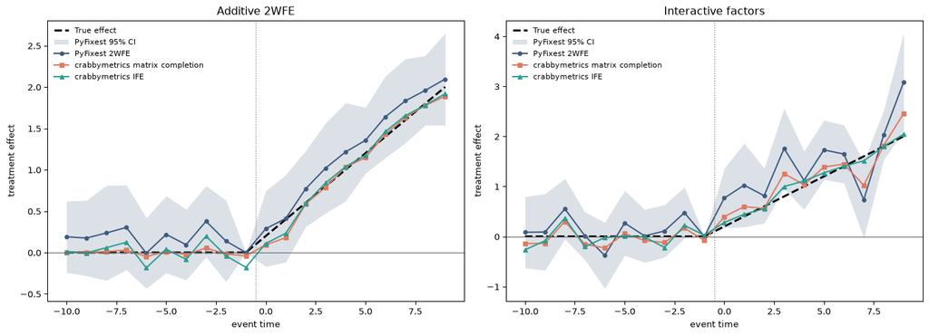

Figure 2: PyFixest and crabbymetrics applied to additive and interactive-factor panels with known treatment effects.

```python
figure, axes = plt.subplots(1, 2, figsize=(14, 5), constrained_layout=True)
for axis, (label, result) in zip(
    axes,
    application_results.items(),
    strict=True,
):
    draw = result["draw"]
    adoption = int(np.unique(draw.adoption_times[draw.treated_units]).item())
    truth = pd.DataFrame(
        {
            "event_time": np.arange(draw.n_periods) - adoption,
            "estimate": draw.treatment_effect[draw.treated_units].mean(axis=0),
        }
    ).query("event_time >= -10")
    pyfixest_event = result["pyfixest"]["event"].query("event_time >= -10")
    matrix_event = result["matrix_completion"]["event"].query(
        "event_time >= -10"
    )
    ife_event = result["interactive_fixed_effects"]["event"].query(
        "event_time >= -10"
    )

    axis.plot(
        truth["event_time"],
        truth["estimate"],
        "--",
        color="black",
        linewidth=2.2,
        label="True effect",
    )
    axis.fill_between(
        pyfixest_event["event_time"],
        pyfixest_event["lower"],
        pyfixest_event["upper"],
        color="#3D5A80",
        alpha=0.18,
        linewidth=0,
        label="PyFixest 95% CI",
    )
    axis.plot(
        pyfixest_event["event_time"],
        pyfixest_event["estimate"],
        "o-",
        color="#3D5A80",
        markersize=4,
        label="PyFixest 2WFE",
    )
    axis.plot(
        matrix_event["event_time"],
        matrix_event["estimate"],
        "s-",
        color="#E07A5F",
        markersize=4,
        label="crabbymetrics matrix completion",
    )
    axis.plot(
        ife_event["event_time"],
        ife_event["estimate"],
        "^-",
        color="#2A9D8F",
        markersize=4,
        label="crabbymetrics IFE",
    )
    axis.axhline(0, color="0.4", linewidth=0.8)
    axis.axvline(-0.5, color="0.5", linewidth=1, linestyle=":")
    axis.set_title(label)
    axis.set_xlabel("event time")
    axis.set_ylabel("treatment effect")
    axis.legend(frameon=False, fontsize=8)
plt.show()
```

For the additive panel, 2WFE is correctly specified. For the interactive panel, the fixed-effects regression omits the latent factors. Matrix completion and the donor-factor estimate use low-rank structure instead. These are illustrative seeded results, not an estimator ranking: matrix completion uses its default penalty fraction, IFE is given the design rank, and only the PyFixest curve includes sampling uncertainty.

## 10 Generate replications

```python
replications = list(simulator.iter_simulations(3, seed=2026))
print([round(item.true_att, 3) for item in replications])
```

```
[1.6, 1.6, 1.6]
```

Use named component streams when a refactor of one component must not change draws from another component:

```python
streams = core.SimulationSeeds.from_seed(2026)
stable_panel = simulator.simulate(streams=streams)
print(stable_panel.shape)
```

```
(200, 40)
```

You can now choose a standard design, specify an assignment mechanism, or read the research design catalog.